# Quantum vortexの分裂を見よう！

量子渦の勉強はよくやるけど, 数式ばっかり見ていてもあまり楽しくないので数値計算で分裂の様子を見ます.

```python
%matplotlib inline

# coding: utf-8

import sys
import numpy as np
from scipy.integrate import simps
from scipy.linalg import solve
from scipy.fftpack import fft2
from scipy.fftpack import ifft2
from scipy.fftpack import fftfreq
import matplotlib.pyplot as plt
import seaborn as sbn
from tqdm import tqdm
```

```python
class GrossPitaevskiiFor1DPolar():

    # --*-- Set constants and variables for initial condition --*--
    def __init__(self, gN=5):

        # Volume, Maximum x-step
        self.L, self.xN = 12, 512

        # Interaction constant, Chemical potential
        self.gN, self.mu, self.kappa = gN, 10, 2

        # Maximum time, Time step
        self.tMax, self.tN = 1, 512

        # x-step, Time step
        self.h, self.dt = self.L/self.xN, self.tMax/self.tN

        # Set x-space
        self.x = np.linspace(0, self.L, self.xN)

        # Set time propagator of poptential term except non-linear term
        self.arr_Psi = self.__Psi_0(self.x)


    # --*-- Set functions --*--

    # Set initial function
    def __Psi_0(self, x): return x**(self.kappa)*np.exp(-x**2/2)


    # Set potential
    def V(self, x): return x**2


    # Make matrix for Crank-Nicolson
    def __MakeCrankMatrix(self):

        a = np.diag(-2 - self.kappa**2/np.arange(1, self.xN+1)**2 + self.h**2*(self.mu - self.V(self.x) - self.gN*self.arr_Psi**2 - 2/self.dt))
        c = np.diag(1 + 0.5/np.arange(0, self.xN))
        c = np.vstack((c[1:], np.array([0]*self.xN)))

        d = np.diag(1 - 0.5/np.arange(1, self.xN+1))
        d = np.vstack((d[1:], np.array([0]*self.xN))).T

        return a + c + d


    # Make vector for Crank-Nicolson
    def __MakeCrankVector(self):

        a = (-2 - self.kappa**2/np.arange(1, self.xN+1)**2 + self.h**2*(self.mu - self.V(self.x) - self.gN*self.arr_Psi**2 + 2/self.dt))*self.arr_Psi
        c = (1 + 0.5/np.arange(1, self.xN+1))*np.hstack((self.arr_Psi[1:], [0]))
        d = (1 - 0.5/np.arange(1, self.xN+1))*np.hstack(([0], self.arr_Psi[:self.xN-1]))

        return -a - c - d

    # Algorithm of Gauss-Seidel
    def __GaussSeidel(self):

        # Set Matrix
        a = self.__MakeCrankMatrix()

        # Set Vector
        b = self.__MakeCrankVector()

        # Solve matrix equation
        self.arr_Psi = solve(a, b)

        # Correction of chemical potential mu
        norm = simps(self.x*self.arr_Psi**2, self.x)/(4*np.pi)
        self.mu -= (norm - 1)/(2*self.dt)

        # Normalize arr_Psi
        self.arr_Psi /= np.sqrt(norm)


    def GaussSeidelLoop(self):

        old_mu = 0
        print("\nGauss-Seidel Start! Please wait...")
        while(np.abs(self.mu - old_mu) > 1e-5):
            old_mu = self.mu
            self.__GaussSeidel()
            sys.stdout.write("\r mu = {0}".format(self.mu))
            sys.stdout.flush()
        print("\nFinished!\n")


    def PrintProcedureFor1D(self):

        # --*-- Matplotlib configuration --*--
        plt.plot(self.x, np.real(self.arr_Psi**2), label="gN = {0}".format(self.gN))
        plt.plot(self.x, self.V(self.x), label="Potential")
        plt.ylim(0, 3)
        plt.xlim(0, 6)
        plt.xlabel("r-space")
        plt.ylabel("Order parameter")
        plt.title("Static vortex of Gross-Pitaevskii equation")
        plt.legend(loc = 'center right')
        plt.show()

    def ProcedureFor1DPolar(self):

        self.GaussSeidelLoop()
        self.PrintProcedureFor1D()
```

## `class GrossPitaevskiiFor1DPolar()`

1次元用のクラス. Crank-Nicolson + Gauss-Seidelでやっています. 極座標表示なので普通のGPとは少し行列・ベクトルの形が違うことに注意.

こんなのが出てきます:

```
Gauss-Seidel Start! Please wait...
 mu = 17.347670393705243
Finished!
```

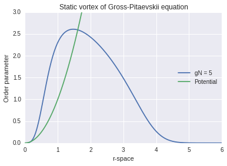

```python
hundle = GrossPitaevskiiFor1DPolar(gN=5)
hundle.ProcedureFor1DPolar()
```

```python
class GrossPitaevskiiFor2D(GrossPitaevskiiFor1DPolar):

    def __init__(self, gN=5):
        super().__init__(gN)

        # -*- For 2D-Symplectic -*-

        # Set xy
        self.I = np.array([1]*self.xN).reshape(self.xN, 1)
        self.x2d = np.linspace(-self.L/2, self.L/2, self.xN)
        self.x22d = self.x2d**2*self.I
        self.xy = np.sqrt(self.x22d + self.x22d.T)

        # Set kx, ky
        kx = 2*np.pi*fftfreq(self.xN, d=1/self.xN)/self.L
        self.kx2d = kx**2*self.I
        self.kxy2d = self.kx2d + self.kx2d.T

        # Set time propagator of poptential term except non-linear term
        self.arr_Psi2D = None
        self.pre_expV = None
        self.expK = None
        self.expV = None


    # Set instable potential
    def __VInst(self, xy):

        x = self.x2d*self.I
        phase = np.cos(self.kappa*np.angle(x + 1j*x.T))

        return xy**2*phase


    # Expand arr_Psi for 2nd Dimension with phase factor
    def __ExpandFor2D(self):

        x = self.x2d * self.I
        phase = np.exp(1j * self.kappa * np.angle(x + 1j*x.T))

        index = np.sqrt(self.x22d + self.x22d.T)/self.h
        index = index.astype(int)

        self.arr_Psi2D = self.arr_Psi[index]*phase


    # Time evolution
    def __Symplectic(self, interval=False):

        self.pre_expV = np.exp(-1j*self.V(self.xy)*self.dt)
        self.pre_expV_inst = np.exp(-1j*self.__VInst(self.xy)*self.dt)
        self.expK = np.exp(-1j*self.kxy2d*self.dt)
        self.expV = np.exp(-1j*(-self.mu + self.gN*np.abs(self.arr_Psi2D)**2)*self.dt)*self.pre_expV_inst

        print("Symplectic Start! Please wait...")

        for i in tqdm(range(self.tN)):
            # Time evolution
            self.arr_Psi2D = ifft2(fft2(self.arr_Psi2D*self.expV)*self.expK)

            # Correction of chemical potential mu
            norm = simps(simps(np.abs(self.arr_Psi2D)**2, self.x2d), self.x2d)
            self.mu -= (norm - 1)/(2*self.dt)

            # Normalization of order parameter arr_Psi
            self.arr_Psi2D /= np.sqrt(norm)

            # Reconfigure expV
            if(i > 20):
                self.expV = np.exp(-1j*(-self.mu + self.gN*np.abs(self.arr_Psi2D)**2)*self.dt)*self.pre_expV
            else:
                self.expV = np.exp(-1j*(-self.mu +self.gN*np.abs(self.arr_Psi2D)**2)*self.dt)*self.pre_expV_inst

            # Print arr_Psi in the middle of time evolution
            if(i is interval):
                self.__PrintProcedureFor2D(type="abs")
                self.__PrintProcedureFor2D(type="angle")

        print("Finished!")


    def __PrintProcedureFor2D(self, type="abs", target=False):

        x = np.arange(self.xN)
        y = np.arange(self.xN)
        X, Y = np.meshgrid(x, y)

        if(target is not False):
            plt.pcolor(X, Y, self.xy)
            plt.colorbar()

        # Print density profile of arr_Psi
        elif(type == "abs"):
            plt.pcolor(X, Y, np.abs(self.arr_Psi2D))
            plt.clim(0, self.arr_Psi.max()/4)
            plt.colorbar()
        # Print phase profile of arr_Psi
        elif(type == "angle"):
            plt.pcolor(X, Y, np.angle(self.arr_Psi2D))

        plt.axis("equal")
        plt.hot()
        plt.xlim(0, self.xN)
        plt.ylim(0, self.xN)
        plt.show()


    def ProcedureForVortex(self):
        self.GaussSeidelLoop()
        self.__ExpandFor2D()
        self.__Symplectic(interval=0)
        self.__PrintProcedureFor2D(type="abs")
        self.__PrintProcedureFor2D(type="angle")
```

## `class GrossPitaevskiiFor2D()`

2次元`xy`座標における秩序変数の時間発展. 1次元用のクラスを継承している. 可能な限り`for-loop`を使わないようにしているので`NumPy`に慣れない人は`__init__()`内や, `expV, expK`などの行列格納で何をしているのか解らないかもしれません. Cだったらfor文で書いて良いです.

こんなのができます:

```
Gauss-Seidel Start! Please wait...
 mu = 17.347670393705243
Finished!
```

```
Symplectic Start! Please wait...
```

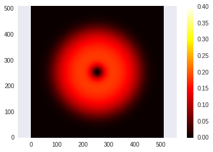

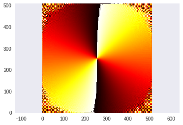

```
Finished!
```

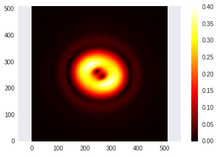

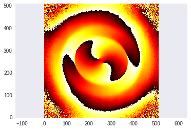

```python
hundle = GrossPitaevskiiFor2D(gN=5)
hundle.ProcedureForVortex()
```

とりあえず渦が2回対称で分裂する様子が見えました. 位相のマップを見ても同じ向きの渦が2つあるのがわかります. 正直ちゃんと計算できているかは不安です. 規格化だったり2次元Symplecticだったりが正確にコーディングできているか...

とりあえず渦が分裂したのは確認できたので良しとします.